# Activity monitoring

## Loading and preprocessing the data

```r
activity_data <- read.csv("C:/Users/paulomauricio/Documents/Jhon's Hopkins/Reproducible research/activity.csv")
str(activity_data)
```

```
## 'data.frame':    17568 obs. of  3 variables:
##  $ steps   : int  NA NA NA NA NA NA NA NA NA NA ...
##  $ date    : Factor w/ 61 levels "2012-10-01","2012-10-02",..: 1 1 1 1 1 1 1 1 1 1 ...
##  $ interval: int  0 5 10 15 20 25 30 35 40 45 ...
```

Set date format and load required libraries

```r
library(lubridate)
library(dplyr)
library(ggplot2)
```

```r
activity_data$date  <- ymd(activity_data$date)
activity_data$steps <- as.numeric(activity_data$steps)
```

## What is mean total number of steps taken per day?

### Calculate the total number of steps taken per day

```r
day_mean <- activity_data %>% group_by(date) %>% summarise(day_mean = mean(steps,na.rm = TRUE))
```

### If you do not understand the difference between a histogram and a barplot, research the difference between them. Make a histogram of the total number of steps taken each day

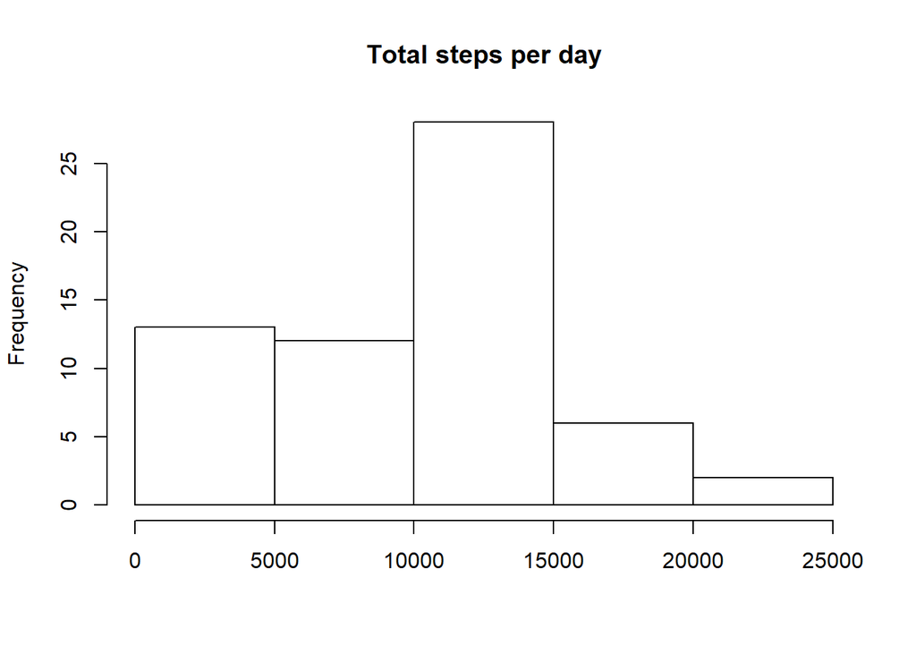

```r
day_total <- activity_data %>% group_by(date) %>% summarise(day_total = sum(steps,na.rm = TRUE))
hist(day_total$day_total,main="Total steps per day",xlab="")
```

### Calculate and report the mean and median of the total number of steps taken per day

```r
mean(day_total$day_total,na.rm = TRUE)
```

```
## [1] 9354.23
```

```r
median(day_total$day_total,na.rm = TRUE)
```

```
## [1] 10395
```

## What is the average daily activity pattern?

### Make a time series plot (i.e. type = “l”) of the 5-minute interval (x-axis) and the average number of steps taken, averaged across all days (y-axis)

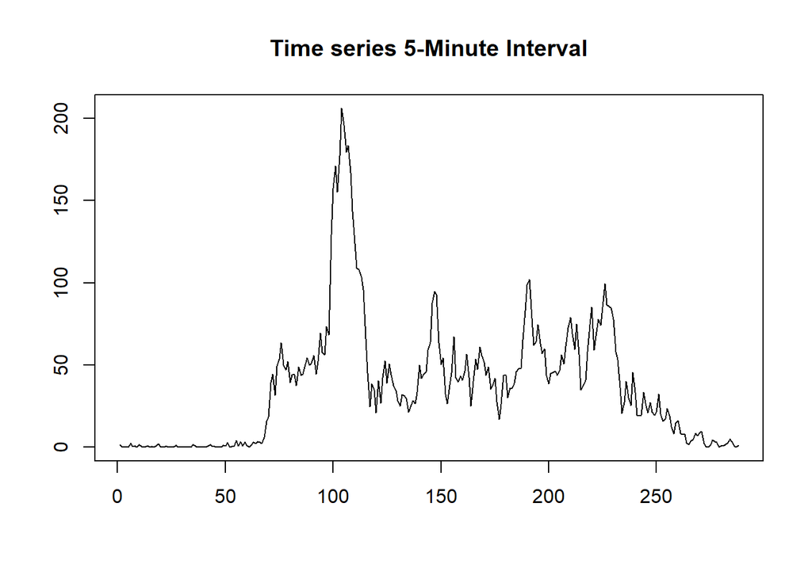

```r
five_min_average <- activity_data %>% group_by(interval) %>% summarise(average = mean(steps,na.rm = TRUE))
plot(ts(five_min_average$average),xlab="",ylab="",main="Time series 5-Minute Interval")
```

### Which 5-minute interval, on average across all the days in the dataset, contains the maximum number of steps?

```r
five_min_average[which.max(five_min_average$average),]
```

```
## # A tibble: 1 x 2
##   interval  average
##      <int>    <dbl>
## 1      835 206.1698
```

## Imputing missing values

### Calculate and report the total number of missing values in the dataset (i.e. the total number of rows with NAs)

```r
summary(activity_data$steps)
```

```
##    Min. 1st Qu.  Median    Mean 3rd Qu.    Max.    NA's
##    0.00    0.00    0.00   37.38   12.00  806.00    2304
```

### Devise a strategy for filling in all of the missing values in the dataset. The strategy does not need to be sophisticated. For example, you could use the mean/median for that day, or the mean for that 5-minute interval, etc.

```r
new.activity <- inner_join(activity_data,five_min_average,by="interval")
new.activity$steps_fill <- ifelse(is.na(new.activity$steps)==TRUE,new.activity$average,new.activity$steps)
```

### Create a new dataset that is equal to the original dataset but with the missing data filled in

```r
activity_data <- inner_join(activity_data,five_min_average,by="interval")
activity_data$steps <- ifelse(is.na(activity_data$steps)==TRUE,activity_data$average,activity_data$steps)
```

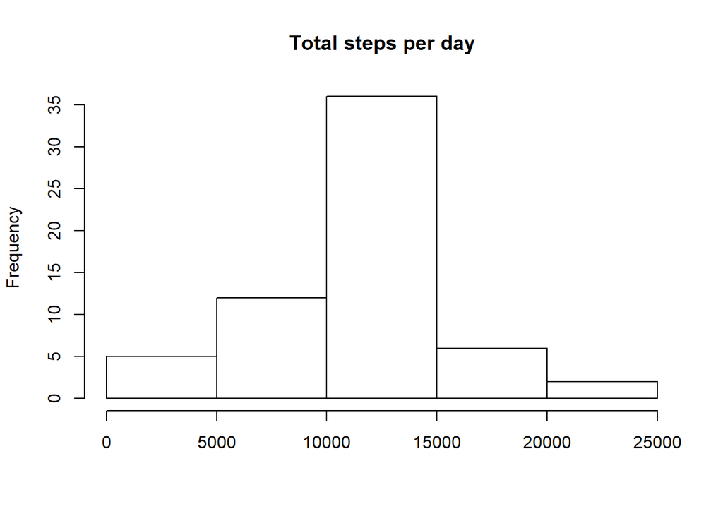

```r
day_total_2 <- activity_data %>% group_by(date) %>% summarise(day_total = sum(steps,na.rm = TRUE))
hist(day_total_2$day_total,main="Total steps per day",xlab="")
```

Histogram of new dataset appears to be normally distributed

## Are there differences in activity patterns between weekdays and weekends?

### Create a new factor variable in the dataset with two levels - “weekday” and “weekend” indicating whether a given date is a weekday or weekend day.

```r
activity_data$week <- ifelse(weekdays(activity_data$date)=="domingo" | weekdays(activity_data$date)=="sábado","weekend","weekday")
```

### Make a panel plot containing a time series plot (i.e. type = “l”) of the 5-minute interval (x-axis) and the average number of steps taken, averaged across all weekday days or weekend days (y-axis). See the README file in the GitHub repository to see an example of what this plot should look like using simulated data.

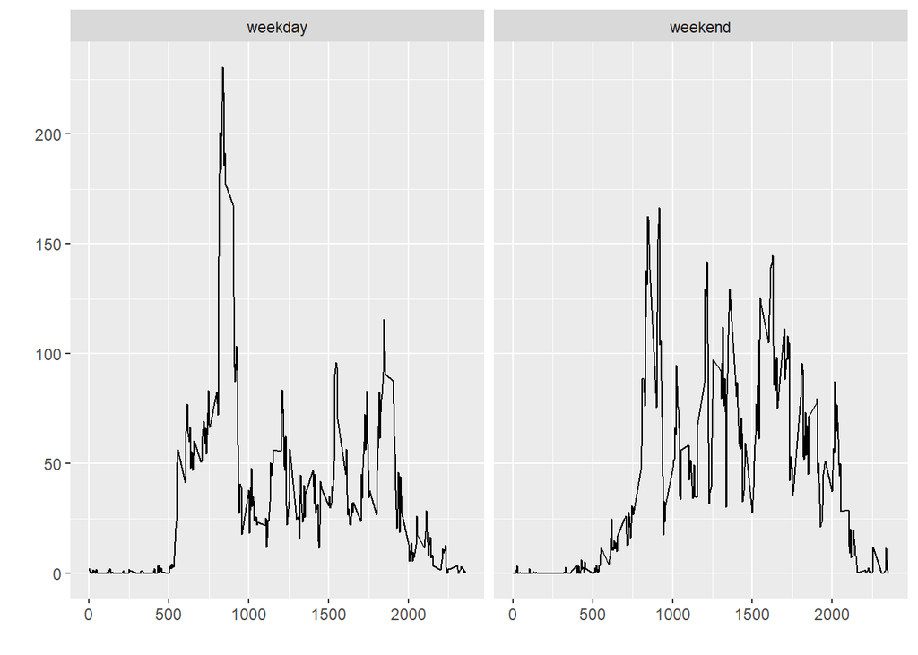

```r
five_min_average_2 <- activity_data %>% group_by(interval,week) %>% summarise(average = mean(steps,na.rm = TRUE))
qplot(interval,average,data = five_min_average_2,facets = .~week,geom = "path",
      xlab = "",ylab = "")
```